# Exploratory Analysis of Hurricane Data Notebook

CHECK PRESENT WORKING DIRECTORY

```r
print(getwd())
```

```
[1] "/home/dell/Documents/hurricanes"
```

IMPORT PACKAGES

```r
library(MASS) # Using fitdistr to fit distributions to data
library(ggplot2) # For plotting scatterplots, line plots, and bar graphs
# library(fitdistrplus) # Using fitdist to fit distributions to data
library(reshape2) # Used to melt correlation matrix
library(dplyr, warn.conflicts = FALSE) # Using %>% to filter data between range
# library(psych) # Using describe() method
```

READ DATASET INTO A DATAFRAME OBJECT

```r
data <- read.csv('data/hurricane_data.csv')
```

CHECK THE FIRST FEW RECORDS OF THE DATA

```r
head(data)
```

```
                          Name Season Max..sustained.winds..km.h. Minimum.pressure..mbar.
1                 Hurricane #3   1853                         240                     924
2 "1856 Last Island hurricane"   1856                         240                     934
3                 Hurricane #6   1866                         220                     938
4                 Hurricane #7   1878                         220                     938
5                 Hurricane #2   1880                         240                     931
6                 Hurricane #8   1880                         220                     928
```

CHANGING NAMES OF COLUMNS IN THE DATAFRAME

```r
colnames(data) <- c("Name", "Year", "Max_sustained_winds", "Min_pressure")
colnames(data)
```

```
[1] "Name"                "Year"                "Max_sustained_winds" "Min_pressure"
```

CHECK THE FIRST FEW RECORDS OF THE DATA

```r
head(data)
```

```
                          Name Year Max_sustained_winds Min_pressure
1                 Hurricane #3 1853                 240          924
2 "1856 Last Island hurricane" 1856                 240          934
3                 Hurricane #6 1866                 220          938
4                 Hurricane #7 1878                 220          938
5                 Hurricane #2 1880                 240          931
6                 Hurricane #8 1880                 220          928
```

CHECK THE LAST FEW RECORDS OF THE DATA

```r
tail(data)
```

```
               Name Year Max_sustained_winds Min_pressure
158 Hurricane Laura 2020                 240          937
159 Hurricane Teddy 2020                 220          945
160 Hurricane Delta 2020                 220          953
161   Hurricane Eta 2020                 240          923
162  Hurricane Iota 2020                 250          917
163   Hurricane Ida 2021                 240          929
```

DESCRIBE DATA

```r
summary(data)
```

```
              Name          Year      Max_sustained_winds  Min_pressure
 Hurricane #4   :  3   Min.   :1853   Min.   :215.0       Min.   :882.0
 Hurricane #6   :  3   1st Qu.:1935   1st Qu.:220.0       1st Qu.:928.0
 Hurricane #2   :  2   Median :1966   Median :230.0       Median :936.0
 Hurricane #3   :  2   Mean   :1966   Mean   :237.7       Mean   :933.9
 Hurricane Betsy:  2   3rd Qu.:2003   3rd Qu.:250.0       3rd Qu.:943.0
 Hurricane Cleo :  2   Max.   :2021   Max.   :305.0       Max.   :975.0
 (Other)        :149
```

CHECKING RANGE OF YEARS IN DATASET

```r
range(data$Year)[2] - range(data$Year)[1]
```

```
[1] 168
```

COMPUTE ANNUAL FREQUENCY OF HURRICANES

```r
Annual_freq <- data.frame(table(data$Year))
colnames(Annual_freq) <- c("Year", "Freq")
Annual_freq
```

```
   Year Freq
1  1853    1
2  1856    1
3  1866    1
4  1878    1
5  1880    2
6  1882    1
7  1886    1
8  1893    1
9  1894    1
10 1898    1
11 1899    1
12 1900    1
13 1906    1
14 1910    1
```

[output cut: 78 more lines]

APPEND ANNUAL FREQUENCY OF HURRICANE TO DATA

```r
Year_freq_vec <- vector(length = length(data))
i <- 1
for (year in data$Year) {
  f <- 0
  for (yr in Annual_freq$Year) {
    if (yr == year) {
      f <- Annual_freq$Freq[Annual_freq$Year == yr]
      break
    }
  }
  Year_freq_vec[i] <- f
  i <- i + 1
}
Year_freq_vec
```

```
  [1] 1 1 1 1 2 2 1 1 1 1 1 1 1 1 1 2 2 1 1 1 1 1 4 4 4 4 1 1 1 1 4 4 4 4 5 5 5 5 5 3 3 3 1 1 1 1 2 2 1 1 2 2 1 3 3 3 2 2 1 1 1 3 3 3 1 3 3 3 1 1 5 5 5 5 5 1 4 4 4 4 1 1 1 1 1 1 1 1 2 2
 [91] 2 2 1 1 1 1 1 3 3 3 2 2 1 1 3 3 3 2 2 2 2 5 5 5 5 5 2 2 2 2 1 2 2 4 4 4 4 5 5 5 5 5 2 2 4 4 4 4 1 4 4 4 4 2 2 1 1 2 2 4 4 4 4 2 2 2 2 5 5 5 5 5 1
```

```r
data <- cbind(data, Year_freq_vec)
head(data)
```

```
                          Name Year Max_sustained_winds Min_pressure Year_freq_vec
1                 Hurricane #3 1853                 240          924             1
2 "1856 Last Island hurricane" 1856                 240          934             1
3                 Hurricane #6 1866                 220          938             1
4                 Hurricane #7 1878                 220          938             1
5                 Hurricane #2 1880                 240          931             2
6                 Hurricane #8 1880                 220          928             2
```

```r
colnames(data)[5] <- c("Freq")
head(data)
```

```
                          Name Year Max_sustained_winds Min_pressure Freq
1                 Hurricane #3 1853                 240          924    1
2 "1856 Last Island hurricane" 1856                 240          934    1
3                 Hurricane #6 1866                 220          938    1
4                 Hurricane #7 1878                 220          938    1
5                 Hurricane #2 1880                 240          931    2
6                 Hurricane #8 1880                 220          928    2
```

COMPUTE DECADES

```r
"---------------Decades---------------------------"
```

```
[1] "---------------Decades---------------------------"
```

```r
decade <- ifelse (data$Year %% 10 == 0, decade <- data$Year - 9, decade <- (data$Year %/% 10) * 10 + 1)
decade
```

```
  [1] 1851 1851 1861 1871 1871 1871 1881 1881 1891 1891 1891 1891 1891 1901 1901 1911 1911 1911 1911 1911 1921 1921 1921 1921 1921 1921 1921 1921 1921 1931 1931 1931 1931 1931 1931 1931
 [37] 1931 1931 1931 1931 1931 1931 1931 1931 1941 1941 1941 1941 1941 1941 1941 1941 1941 1941 1941 1941 1951 1951 1951 1951 1951 1951 1951 1951 1951 1951 1951 1951 1951 1951 1961 1961
 [73] 1961 1961 1961 1961 1961 1961 1961 1961 1961 1961 1961 1961 1971 1971 1971 1971 1971 1971 1971 1971 1971 1981 1981 1981 1981 1981 1981 1981 1981 1981 1991 1991 1991 1991 1991 1991
[109] 1991 1991 1991 1991 1991 1991 1991 1991 1991 1991 2001 2001 2001 2001 2001 2001 2001 2001 2001 2001 2001 2001 2001 2001 2001 2001 2001 2001 2001 2001 2001 2001 2001 2001 2001 2011
[145] 2011 2011 2011 2011 2011 2011 2011 2011 2011 2011 2011 2011 2011 2011 2011 2011 2011 2011 2021
```

```r
"----------------Years------------------------"
```

```
[1] "----------------Years------------------------"
```

```r
as.numeric(as.character(data$Year))
```

```
  [1] 1853 1856 1866 1878 1880 1880 1882 1886 1893 1894 1898 1899 1900 1906 1910 1915 1915 1916 1917 1919 1921 1924 1926 1926 1926 1926 1928 1929 1930 1931 1932 1932 1932 1932 1933 1933
 [37] 1933 1933 1933 1935 1935 1935 1938 1939 1941 1943 1944 1944 1945 1947 1948 1948 1949 1950 1950 1950 1951 1951 1952 1953 1954 1955 1955 1955 1957 1958 1958 1958 1959 1960 1961 1961
 [73] 1961 1961 1961 1963 1964 1964 1964 1964 1965 1966 1967 1969 1971 1974 1975 1977 1978 1978 1979 1979 1980 1981 1982 1984 1985 1988 1988 1988 1989 1989 1991 1992 1995 1995 1995 1996
[109] 1996 1998 1998 1999 1999 1999 1999 1999 2000 2000 2001 2001 2002 2003 2003 2004 2004 2004 2004 2005 2005 2005 2005 2005 2007 2007 2008 2008 2008 2008 2009 2010 2010 2010 2010 2011
[145] 2011 2014 2015 2016 2016 2017 2017 2017 2017 2018 2018 2019 2019 2020 2020 2020 2020 2020 2021
```

```r
"---------------------------------------------"
```

```
[1] "---------------------------------------------"
```

APPEND DECADE TO DATAFRAME

```r
data <- cbind(data, decade)
data
```

```
                                   Name Year Max_sustained_winds Min_pressure Freq decade
1                          Hurricane #3 1853                 240          924    1   1851
2          "1856 Last Island hurricane" 1856                 240          934    1   1851
3                          Hurricane #6 1866                 220          938    1   1861
4                          Hurricane #7 1878                 220          938    1   1871
5                          Hurricane #2 1880                 240          931    2   1871
6                          Hurricane #8 1880                 220          928    2   1871
7                          Hurricane #6 1882                 220          975    1   1881
8              1886 Indianola hurricane 1886                 240          925    1   1881
9                         Hurricane #10 1893                 215          948    1   1891
10                         Hurricane #6 1894                 215          931    1   1891
11               1898 Georgia hurricane 1898                 215          930    1   1891
12           1899 San Ciriaco hurricane 1899                 240          930    1   1891
13             1900 Galveston hurricane 1900                 230          936    1   1891
14                         Hurricane #4 1906                 215          950    1   1901
```

[output cut: 149 more lines]

COMPUTE DECADAL FREQUENCY

```r
decadal_freq <- data.frame(table(data$decade))
colnames(decadal_freq) <- c("Decade", "Freq")
decadal_freq
```

```
   Decade Freq
1    1851    2
2    1861    1
3    1871    3
4    1881    2
5    1891    5
6    1901    2
7    1911    5
8    1921    9
9    1931   15
10   1941   12
11   1951   14
12   1961   14
13   1971    9
14   1981    9
15   1991   16
16   2001   25
17   2011   19
18   2021    1
```

APPEND DECADAL FREQUENCY TO DATAFRAME

```r
Dec_freq_vec <- vector(length = length(data))
i <- 1
for (decade in data$decade) {
  f <- 0
  for (dec in decadal_freq$Decade) {
    if (dec == decade) {
      f <- decadal_freq$Freq[decadal_freq$Decade == dec]
      break
    }
  }
  Dec_freq_vec[i] <- f
  i <- i + 1
}
Dec_freq_vec
```

```
  [1]  2  2  1  3  3  3  2  2  5  5  5  5  5  2  2  5  5  5  5  5  9  9  9  9  9  9  9  9  9 15 15 15 15 15 15 15 15 15 15 15 15 15 15 15 12 12 12 12 12 12 12 12 12 12 12 12 14 14 14 14
 [61] 14 14 14 14 14 14 14 14 14 14 14 14 14 14 14 14 14 14 14 14 14 14 14 14  9  9  9  9  9  9  9  9  9  9  9  9  9  9  9  9  9  9 16 16 16 16 16 16 16 16 16 16 16 16 16 16 16 16 25 25
[121] 25 25 25 25 25 25 25 25 25 25 25 25 25 25 25 25 25 25 25 25 25 25 25 19 19 19 19 19 19 19 19 19 19 19 19 19 19 19 19 19 19 19  1
```

```r
data <- cbind(data, Dec_freq_vec)
head(data)
```

```
                          Name Year Max_sustained_winds Min_pressure Freq decade Dec_freq_vec
1                 Hurricane #3 1853                 240          924    1   1851            2
2 "1856 Last Island hurricane" 1856                 240          934    1   1851            2
3                 Hurricane #6 1866                 220          938    1   1861            1
4                 Hurricane #7 1878                 220          938    1   1871            3
5                 Hurricane #2 1880                 240          931    2   1871            3
6                 Hurricane #8 1880                 220          928    2   1871            3
```

```r
colnames(data)[7] <- c("Dec_Freq")
head(data)
```

```
                          Name Year Max_sustained_winds Min_pressure Freq decade Dec_Freq
1                 Hurricane #3 1853                 240          924    1   1851        2
2 "1856 Last Island hurricane" 1856                 240          934    1   1851        2
3                 Hurricane #6 1866                 220          938    1   1861        1
4                 Hurricane #7 1878                 220          938    1   1871        3
5                 Hurricane #2 1880                 240          931    2   1871        3
6                 Hurricane #8 1880                 220          928    2   1871        3
```

DATA VISUALIZATION

PLOTTING FREQUENCY OF HURRICANES

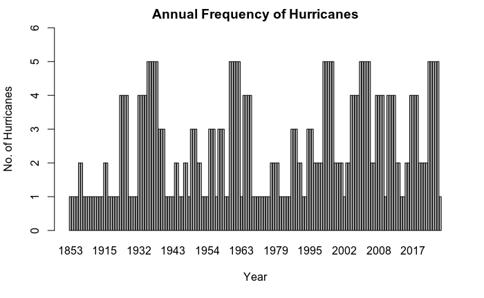

```r
barplot(height = data$Freq, width = 10, names.arg = data$Year,
        ylim = c(0, 6), xpd = FALSE,
        main = "Annual Frequency of Hurricanes", xlab = "Year", ylab = "No. of Hurricanes")
```

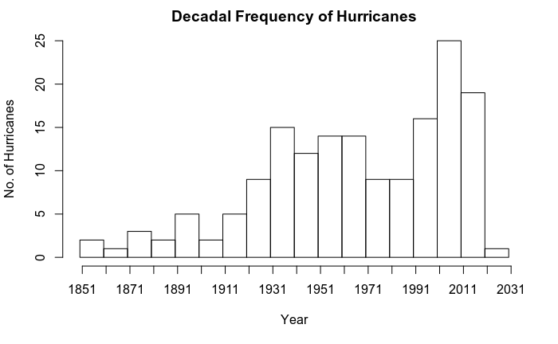

```r
no_of_intervals <- (2030-1851) / 10
hist(data$Year, breaks = no_of_intervals, main = "Decadal Frequency of Hurricanes", xlab = "Year", ylab = "No. of Hurricanes", xaxt = 'n')
axis(side=1, at=seq(1851, 2040, 10), labels=seq(1851, 2040, 10))
```

CHECKING MAX_SUSTAINED_WINDS OF EACH HURRICANE

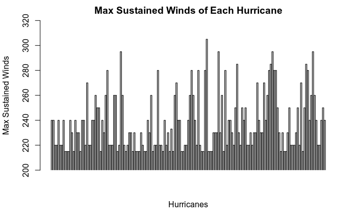

```r
barplot(height = data$Max_sustained_winds, width = 10,
        ylim = c(200, 320), xpd = FALSE,
        main = "Max Sustained Winds of Each Hurricane", xlab = "Hurricanes", ylab = "Max Sustained Winds")
```

CHECKING MIN_PRESSURE OF EACH HURRICANE

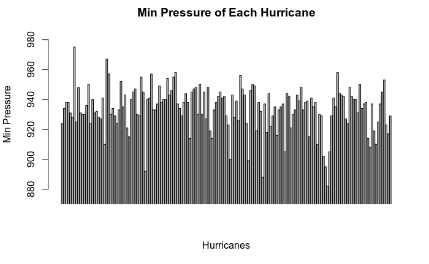

```r
barplot(height = data$Min_pressure, width = 10,
        ylim = c(870, 990), xpd = FALSE,
        main = "Min Pressure of Each Hurricane", xlab = "Hurricanes", ylab = "Min Pressure")
```

CHECKING SCATTERPLOTS OF TIME AND MAX_SUSTAINED_WINDS

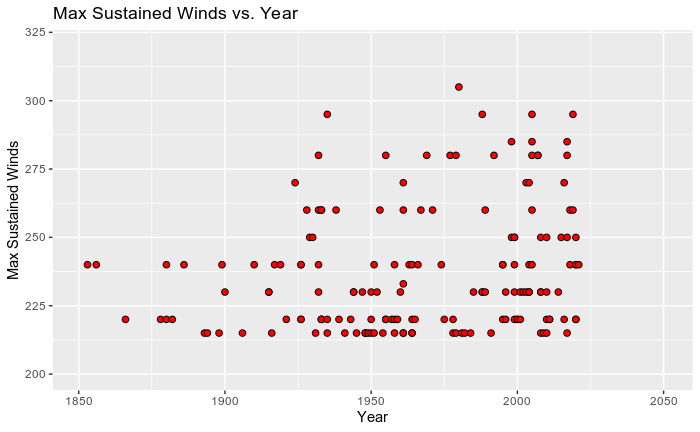

```r
# Year
ggplot(data, aes(x = Year, y = Max_sustained_winds)) + xlim(c(1851, 2050)) + ylim(c(200, 320)) + geom_point(fill = "red", size = 2, shape = 21) + ggtitle("Max Sustained Winds vs. Year") + xlab("Year") + ylab("Max Sustained Winds")
```

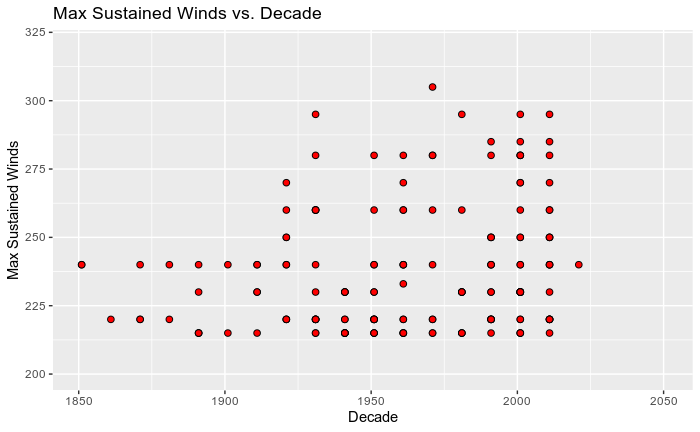

```r
# Decade
ggplot(data, aes(x = decade, y = Max_sustained_winds)) + xlim(c(1851, 2050)) + ylim(c(200, 320)) + geom_point(fill = "red", size = 2, shape = 21) + ggtitle("Max Sustained Winds vs. Decade") + xlab("Decade") + ylab("Max Sustained Winds")
```

CHECKING SCATTERPLOTS OF TIME AND MIN_PRESSURE

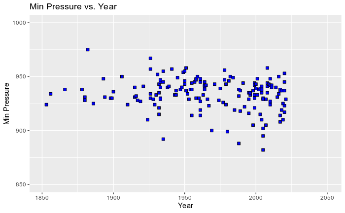

```r
# Year
ggplot(data, aes(x = Year, y = Min_pressure)) + ylim(850, 1000) + xlim(1851, 2050) + geom_point(fill = "blue", size = 2, shape = 22) + ggtitle("Min Pressure vs. Year") + xlab("Year") + ylab("Min Pressure")
```

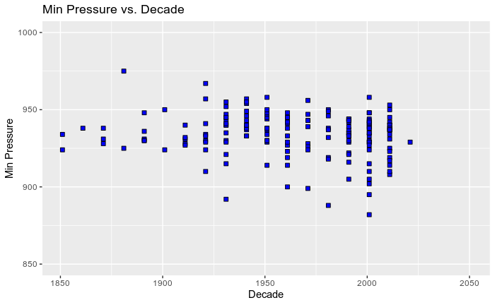

```r
# Decade
ggplot(data, aes(x = decade, y = Min_pressure)) + ylim(850, 1000) + xlim(1851, 2050) + geom_point(fill = "blue", size = 2, shape = 22) + ggtitle("Min Pressure vs. Decade") + xlab("Decade") + ylab("Min Pressure")
```

CHECKING SCATTERPLOT OF MAX SUSTAINED WINDS AND MIN PRESSURE

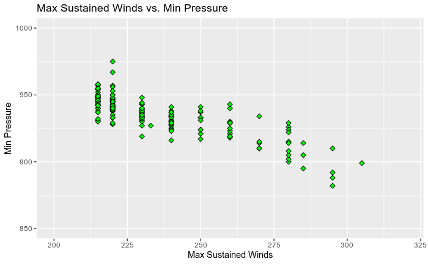

```r
ggplot(data, aes(x = Max_sustained_winds, y = Min_pressure)) + ylim(850, 1000) + xlim(200, 320) + geom_point(fill = "green", size = 2, shape = 23) + ggtitle("Max Sustained Winds vs. Min Pressure") + xlab("Max Sustained Winds") + ylab("Min Pressure")
```

CHECKING SCATTERPLOT OF FREQUENCY AND MAX SUSTAINED WINDS

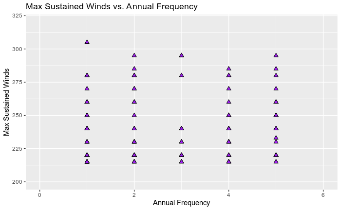

```r
# Annual Frequency
ggplot(data, aes(x = Freq, y = Max_sustained_winds)) + xlim(0, 6) + ylim(200, 320) + geom_point(fill = "purple", size = 2, shape = 24) + ggtitle("Max Sustained Winds vs. Annual Frequency") + ylab("Max Sustained Winds") + xlab("Annual Frequency")
```

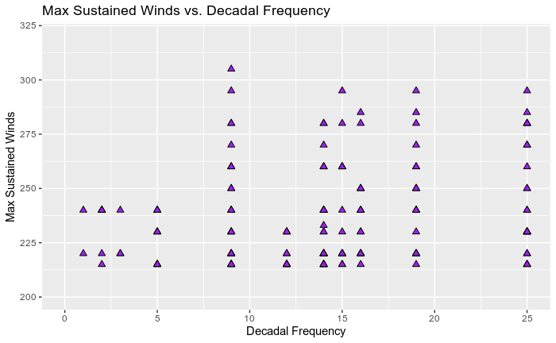

```r
# Decadal Frequency
ggplot(data, aes(x = Dec_Freq, y = Max_sustained_winds)) + xlim(0, 25) + ylim(200, 320) + geom_point(fill = "purple", size = 2, shape = 24) + ggtitle("Max Sustained Winds vs. Decadal Frequency") + ylab("Max Sustained Winds") + xlab("Decadal Frequency")
```

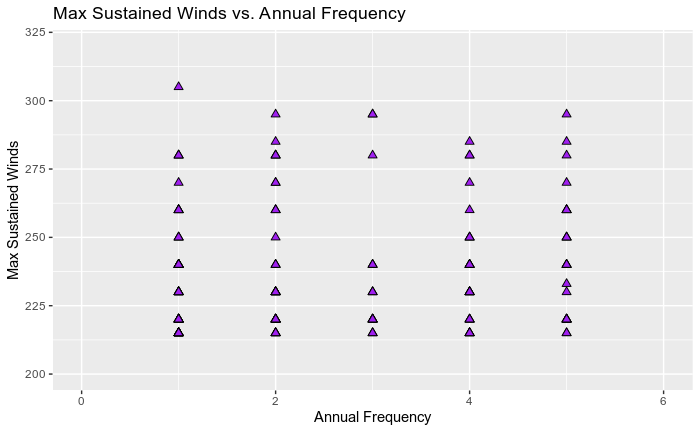

```r
# For Annual Frequency
ggplot(data, aes(x = Freq, y = Max_sustained_winds)) + xlim(0, 6) + ylim(200, 320) + geom_point(fill = "purple", size = 2, shape = 24) + ggtitle("Max Sustained Winds vs. Annual Frequency") + ylab("Max Sustained Winds") + xlab("Annual Frequency")
```

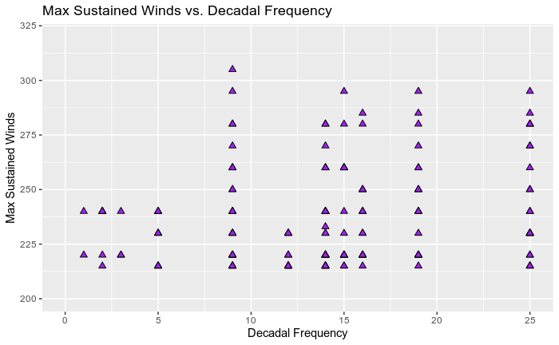

```r
# For Decadal Frequency
ggplot(data, aes(x = Dec_Freq, y = Max_sustained_winds)) + xlim(0, 25) + ylim(200, 320) + geom_point(fill = "purple", size = 2, shape = 24) + ggtitle("Max Sustained Winds vs. Decadal Frequency") + ylab("Max Sustained Winds") + xlab("Decadal Frequency")
```

CHECKING CORRELATION MATRIX OF NUMERICAL DATA

```r
cor_mat <- round(cor(data[-1]),2)
cor_mat
```

```
                     Year Max_sustained_winds Min_pressure  Freq decade Dec_Freq
Year                 1.00                0.22        -0.16  0.34   1.00     0.76
Max_sustained_winds  0.22                1.00        -0.83  0.11   0.21     0.19
Min_pressure        -0.16               -0.83         1.00 -0.09  -0.16    -0.13
Freq                 0.34                0.11        -0.09  1.00   0.34     0.48
decade               1.00                0.21        -0.16  0.34   1.00     0.77
Dec_Freq             0.76                0.19        -0.13  0.48   0.77     1.00
```

DRAWING HEATMAP OF CORRELATION MATRIX

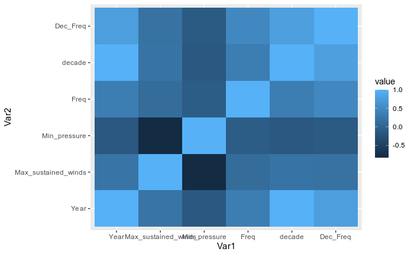

```r
melted_cor_mat <- melt(cor_mat)
ggplot(data = melted_cor_mat, aes(x=Var1, y=Var2, fill=value)) + geom_tile()
```

FITTING TO DISTRIBUTION

COLLECT EMPIRICAL VALUES OF FREQUENCY DISTRIBUTION FROM GIVEN DATASET

COMPUTE ANNUAL HURRICANE FREQUENCY DISTRIBUTION, that is, ANNUAL EMPIRICAL VALUES

```r
All_years <- seq(1851, 2030)
All_years
```

```
  [1] 1851 1852 1853 1854 1855 1856 1857 1858 1859 1860 1861 1862 1863 1864 1865 1866 1867 1868 1869 1870 1871 1872 1873 1874 1875 1876 1877 1878 1879 1880 1881 1882 1883 1884 1885 1886
 [37] 1887 1888 1889 1890 1891 1892 1893 1894 1895 1896 1897 1898 1899 1900 1901 1902 1903 1904 1905 1906 1907 1908 1909 1910 1911 1912 1913 1914 1915 1916 1917 1918 1919 1920 1921 1922
 [73] 1923 1924 1925 1926 1927 1928 1929 1930 1931 1932 1933 1934 1935 1936 1937 1938 1939 1940 1941 1942 1943 1944 1945 1946 1947 1948 1949 1950 1951 1952 1953 1954 1955 1956 1957 1958
[109] 1959 1960 1961 1962 1963 1964 1965 1966 1967 1968 1969 1970 1971 1972 1973 1974 1975 1976 1977 1978 1979 1980 1981 1982 1983 1984 1985 1986 1987 1988 1989 1990 1991 1992 1993 1994
[145] 1995 1996 1997 1998 1999 2000 2001 2002 2003 2004 2005 2006 2007 2008 2009 2010 2011 2012 2013 2014 2015 2016 2017 2018 2019 2020 2021 2022 2023 2024 2025 2026 2027 2028 2029 2030
```

```r
annual_empirical_values <- vector(length = length(All_years))
i <- 1
for (year in All_years) {
  f <- 0
  for (yr in Annual_freq$Year) {
    if (yr == year) {
      f <- Annual_freq$Freq[Annual_freq$Year == yr]
      break
    }
  }
  annual_empirical_values[i] <- f
  i <- i + 1
}
annual_empirical_values
```

```
  [1] 0 0 1 0 0 1 0 0 0 0 0 0 0 0 0 1 0 0 0 0 0 0 0 0 0 0 0 1 0 2 0 1 0 0 0 1 0 0 0 0 0 0 1 1 0 0 0 1 1 1 0 0 0 0 0 1 0 0 0 1 0 0 0 0 2 1 1 0 1 0 1 0 0 1 0 4 0 1 1 1 1 4 5 0 3 0 0 1 1 0
 [91] 1 0 1 2 1 0 1 2 1 3 2 1 1 1 3 0 1 3 1 1 5 0 1 4 1 1 1 0 1 0 1 0 0 1 1 0 1 2 2 1 1 1 0 1 1 0 0 3 2 0 1 1 0 0 3 2 0 2 5 2 2 1 2 4 5 0 2 4 1 4 2 0 0 1 1 2 4 2 2 5 1 0 0 0 0 0 0 0 0 0
```

COLLECT DECADAL HURRICANE FREQUENCY DISTRIBUTION, that is, DECADAL EMPIRICAL VALUES

```r
decadal_empirical_values <- decadal_freq$Freq
decadal_empirical_values
```

```
 [1]  2  1  3  2  5  2  5  9 15 12 14 14  9  9 16 25 19  1
```

COMPUTE FIT TO NORMAL DISTRIBUTION

```r
normal.fit.annual <- fitdistr(annual_empirical_values, "normal")
"---------Normal Fit to Annual Empirical Values--------------"
```

```
[1] "---------Normal Fit to Annual Empirical Values--------------"
```

```r
normal.fit.annual
```

```
      mean          sd
  0.90555556   1.22790346
 (0.09152252) (0.06471619)
```

```r
normal.fit.decadal <-fitdistr(decadal_empirical_values, "normal")
"---------Normal Fit to Decadal Empirical Values--------------"
```

```
[1] "---------Normal Fit to Decadal Empirical Values--------------"
```

```r
normal.fit.decadal
```

```
     mean        sd
  9.055556   6.843263
 (1.612973) (1.140544)
```

COMPUTE THEORETICAL NORMAL QUANTILES

```r
theoretical_normal_quantiles.annual <- rnorm(n = 180, mean = normal.fit.annual$estimate[1], sd = normal.fit.annual$estimate[2])
"---------------Theoretical Normal Quantiles (Annual)-----------------------------------"
```

```
[1] "---------------Theoretical Normal Quantiles (Annual)-----------------------------------"
```

```r
theoretical_normal_quantiles.annual
```

```
  [1]  1.55859178  0.35740136  0.59104900  1.87103655  3.29342540  0.56345210  3.58859752  0.48501898  1.13856400 -0.11473350  1.24619711 -0.62157753  1.52567565  1.20377072  1.59642709
 [16]  0.31652740  3.19420339 -0.74617898  1.11361117  0.27568332  3.13365760  1.52873794  2.88299890 -1.10384165  0.53534799  1.70869522 -0.26430220  0.01710749  0.29262956  1.74170486
 [31]  0.44366507 -0.20975766 -1.40615039  1.16449429  2.02142128  0.93619483  2.00368538  0.06102313  0.40594600  0.68631553  0.59557306  2.49232984 -0.65989316 -0.56751850  0.31362248
 [46]  0.67751689 -0.76882702 -0.69672350 -0.16065059 -0.38352853 -1.07561834 -0.12994511 -1.32755969  1.44201638  0.67576756  0.31379605  1.12770943  0.90107504  0.26053754  1.08121640
 [61]  2.27288172  1.68931941  1.87631827  0.98867976 -1.02964017  1.60640566  1.30006161  2.14865587 -0.07942436  1.35492044 -0.23880255 -0.45659366  1.15212350 -0.06819270 -0.20977762
 [76]  1.03891169  0.95690276 -0.75186812 -0.60888532  0.85805032  0.40727713  2.45080475  0.80870350  2.34530444  1.18393889  2.27507146  1.11508723  1.27025939  2.39249482 -0.43341178
 [91] -0.26735044 -0.28083757 -0.56325267 -0.90668393  0.60894788  1.53138022  2.38961030  2.17162623  2.16086025 -0.91344295 -0.05076598  1.09558844 -1.40593504 -3.57876571  2.18570654
[106]  2.25041198 -0.88825823  1.62140277  0.88913131  0.84774111  3.59494093  0.39196256 -0.41888060  1.69717089  3.10995374 -0.74133336  0.60029971  1.79413884  0.92311548  0.93143713
[121] -1.66221664  2.48817401  1.61243906  2.88425451  1.07735037 -0.91289306  1.14314412  0.39084944  1.17736250 -0.47835400  1.31678402  1.97922249  1.44556076  2.18761969  0.48820838
[136]  1.75864288  1.34879652  2.37535967  3.48368042  1.13085575  0.61604442  0.41845231  2.50346679  1.35835309 -0.66380547 -0.02364851  1.04217249  2.76061277  0.28131993  0.90437183
[151]  1.07224951  1.15821643 -0.23496536 -0.41534585  2.45170685  1.43486700  0.51804972  0.03820530  1.82672426 -0.09550567  0.03650511  1.41572519  1.93602119 -1.47814484  0.71191412
[166] -0.97055061 -0.10717923 -0.11533270  1.04655729  1.43920783  1.27237882 -1.04218255 -0.73462180  0.52782348  1.43193564  1.76021482  2.27987783 -0.27088346  1.41679903 -0.40256831
```

```r
"-----------------------------------------------------------------------------------------"
```

```
[1] "-----------------------------------------------------------------------------------------"
```

```r
theoretical_normal_quantiles.decadal <- rnorm(n = 18, mean = normal.fit.decadal$estimate[1], sd = normal.fit.decadal$estimate[2])
"---------------Theoretical Normal Quantiles (Decadal)-----------------------------------"
```

```
[1] "---------------Theoretical Normal Quantiles (Decadal)-----------------------------------"
```

```r
theoretical_normal_quantiles.decadal
```

```
 [1]  8.9934572 10.1022313 -5.2904099  0.3932575  3.5542445  7.8919380 23.1327717 10.4391950 -2.2662053  8.8360616  3.2309522  0.2515701  7.4484784  7.9295149 13.3399476 10.3228047
[17]  1.3738554 12.3673348
```

PLOT QUANTILE-QUANTILE PLOT FOR EMPIRICAL VALUES AND THEORETICAL VALUES

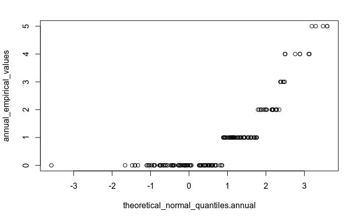

```r
# Annual
qqplot(theoretical_normal_quantiles.annual, annual_empirical_values)
```

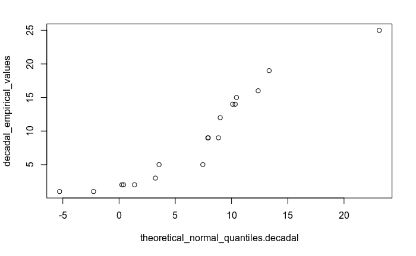

```r
# Decadal
qqplot(theoretical_normal_quantiles.decadal, decadal_empirical_values)
```

COMPUTE FIT TO NEGATIVE BINOMIAL DISTRIBUTION

```r
negbinomial.fit.annual <- fitdistr(annual_empirical_values, "negative binomial")
"---------Negative Binomial Fit to Annual Empirical Values--------------"
```

```
[1] "---------Negative Binomial Fit to Annual Empirical Values--------------"
```

```r
negbinomial.fit.annual
```

```
      size          mu
  1.37493552   0.90555607
 (0.42859559) (0.09134691)
```

```r
negbinomial.fit.decadal <- fitdistr(decadal_empirical_values, "negative binomial")
"---------Negative Binomial Fit to Decadal Empirical Values--------------"
```

```
[1] "---------Negative Binomial Fit to Decadal Empirical Values--------------"
```

```r
negbinomial.fit.decadal
```

```
     size         mu
  1.7540263   9.0555556
 (0.6952243) (1.7607905)
```

COMPUTE THEORETICAL NEGATIVE BINOMIAL QUANTILES

```r
theoretical_negbinomial_quantiles.annual <- rnbinom(n = 180, size = negbinomial.fit.annual$estimate[1], mu = negbinomial.fit.annual$estimate[2])
"---------------Theoretical Negative Binomial Quantiles (Annual)-----------------------------------"
```

```
[1] "---------------Theoretical Negative Binomial Quantiles (Annual)-----------------------------------"
```

```r
theoretical_negbinomial_quantiles.annual
```

```
  [1] 0 0 0 1 0 0 0 1 3 1 0 0 0 1 0 2 3 1 0 0 0 0 2 0 0 1 0 1 1 2 1 1 0 2 0 0 1 2 0 0 1 1 2 4 1 0 0 1 1 1 2 0 3 0 1 1 0 0 1 0 0 0 0 2 1 4 0 1 0 1 1 0 0 0 2 1 0 1 0 1 2 0 0 0 2 0 0 0 0 0
 [91] 0 0 2 2 0 1 0 0 0 5 0 0 0 0 0 3 3 5 0 0 2 1 0 2 3 0 2 0 1 2 0 0 0 1 2 0 4 0 1 0 3 0 0 1 0 0 1 1 0 0 0 2 1 0 0 0 0 0 4 2 1 0 0 1 1 0 0 0 1 1 1 1 1 0 0 2 2 0 6 0 2 0 0 0 0 1 0 0 0 0
```

```r
"-----------------------------------------------------------------------------------------"
```

```
[1] "-----------------------------------------------------------------------------------------"
```

```r
theoretical_negbinomial_quantiles.decadal <- rnbinom(n = 18, size = negbinomial.fit.decadal$estimate[1], mu = negbinomial.fit.decadal$estimate[2])
"---------------Theoretical Negative Binomial Quantiles (Decadal)-----------------------------------"
```

```
[1] "---------------Theoretical Negative Binomial Quantiles (Decadal)-----------------------------------"
```

```r
theoretical_negbinomial_quantiles.decadal
```

```
 [1]  2  6 13  2  1  7  6  0  2 12  5 39  3  6 19 11  2 17
```

PLOT QUANTILE-QUANTILE PLOT FOR EMPIRICAL VALUES AND THEORETICAL VALUES

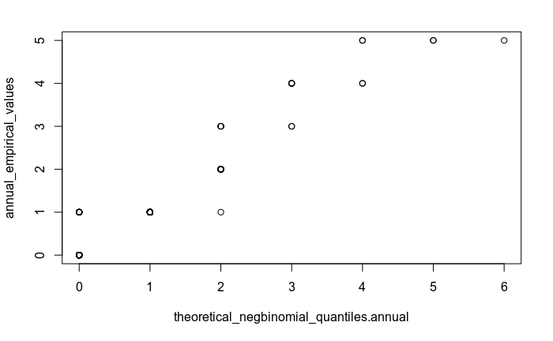

```r
# Annual
qqplot(theoretical_negbinomial_quantiles.annual, annual_empirical_values)
```

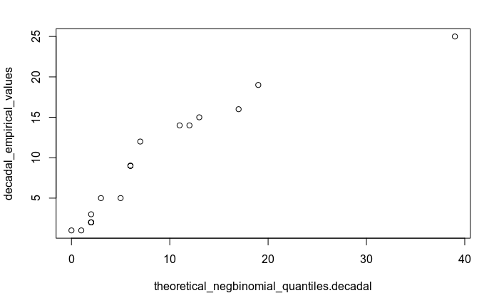

```r
# Decadal
qqplot(theoretical_negbinomial_quantiles.decadal, decadal_empirical_values)
```

COMPUTE FIT TO GEOMETRIC DISTRIBUTION

```r
geometric.fit.annual <- fitdistr(annual_empirical_values, "geometric")
"---------Geometric Fit to Annual Empirical Values--------------"
```

```
[1] "---------Geometric Fit to Annual Empirical Values--------------"
```

```r
geometric.fit.annual
```

```
      prob
  0.52478134
 (0.02696428)
```

```r
geometric.fit.decadal <- fitdistr(decadal_empirical_values, "geometric")
"---------Geometric Fit to Decadal Empirical Values--------------"
```

```
[1] "---------Geometric Fit to Decadal Empirical Values--------------"
```

```r
geometric.fit.decadal
```

```
      prob
  0.09944751
 (0.02224396)
```

COMPUTE THEORETICAL GEOMETRIC QUANTILES

```r
theoretical_geometric_quantiles.annual <- rgeom(n = 180, prob = geometric.fit.annual$estimate)
"---------------Theoretical Geometric Quantiles (Annual)-----------------------------------"
```

```
[1] "---------------Theoretical Geometric Quantiles (Annual)-----------------------------------"
```

```r
theoretical_geometric_quantiles.annual
```

```
  [1] 0 0 0 1 0 1 0 0 3 1 0 0 0 3 0 0 1 1 0 5 1 0 0 0 0 0 0 2 1 0 1 3 0 1 1 0 0 0 1 1 0 1 4 0 0 0 2 1 1 3 3 3 3 1 0 1 1 1 2 0 0 0 0 0 0 2 0 0 1 0 0 0 0 2 0 0 0 0 0 0 1 3 2 3 2 1 0 0 1 0
 [91] 0 0 0 2 0 2 2 2 0 1 0 0 0 0 1 0 0 0 0 0 4 0 3 0 0 0 0 0 0 0 0 3 0 0 0 4 2 0 0 1 1 2 0 0 1 0 1 0 0 0 0 0 0 1 2 0 1 0 3 1 0 2 0 4 0 1 2 0 4 0 1 0 0 9 0 1 1 0 0 2 0 0 1 0 0 0 0 0 0 3
```

```r
"-----------------------------------------------------------------------------------------"
```

```
[1] "-----------------------------------------------------------------------------------------"
```

```r
theoretical_geometric_quantiles.decadal <- rgeom(n = 18, prob = geometric.fit.decadal$estimate)
"---------------Theoretical Geometric Quantiles (Decadal)-----------------------------------"
```

```
[1] "---------------Theoretical Geometric Quantiles (Decadal)-----------------------------------"
```

```r
theoretical_geometric_quantiles.decadal
```

```
 [1] 19 13  7  8  0  8  7  4 33  0  9  1  2  3  7  7  4 12
```

PLOT QUANTILE-QUANTILE PLOT FOR EMPIRICAL VALUES AND THEORETICAL VALUES

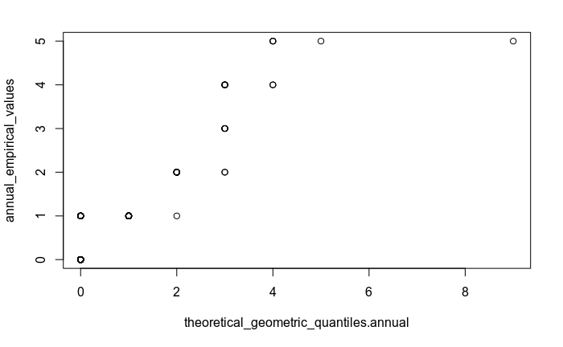

```r
# Annual
qqplot(theoretical_geometric_quantiles.annual, annual_empirical_values)
```

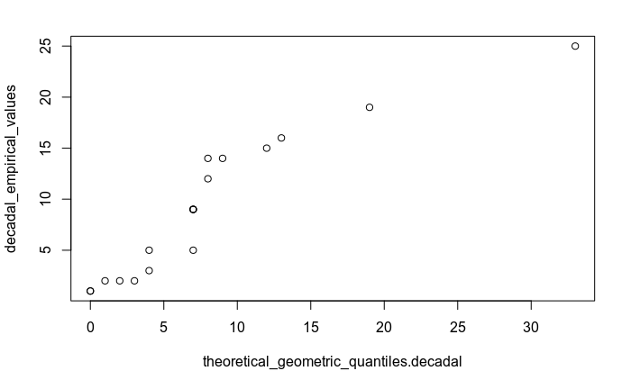

```r
# Decadal
qqplot(theoretical_geometric_quantiles.decadal, decadal_empirical_values)
```

COMPUTE FIT TO POISSON DISTRIBUTION

```r
poisson.fit.annual <- fitdistr(annual_empirical_values, "poisson")
"---------Poisson Fit to Annual Empirical Values--------------"
```

```
[1] "---------Poisson Fit to Annual Empirical Values--------------"
```

```r
poisson.fit.annual
```

```
     lambda
  0.90555556
 (0.07092859)
```

```r
poisson.fit.decadal <- fitdistr(decadal_empirical_values, "poisson")
"---------Poisson Fit to Decadal Empirical Values--------------"
```

```
[1] "---------Poisson Fit to Decadal Empirical Values--------------"
```

```r
poisson.fit.decadal
```

```
    lambda
  9.0555556
 (0.7092859)
```

COMPUTE THEORETICAL POISSON QUANTILES

```r
theoretical_poisson_quantiles.annual <- rpois(n = 180, lambda = poisson.fit.annual$estimate)
"---------------Theoretical Poisson Quantiles (Annual)-----------------------------------"
```

```
[1] "---------------Theoretical Poisson Quantiles (Annual)-----------------------------------"
```

```r
theoretical_poisson_quantiles.annual
```

```
  [1] 2 0 2 1 0 0 0 1 0 2 2 0 3 2 3 0 0 0 1 3 2 0 0 0 2 2 0 4 0 0 1 1 1 1 2 0 0 0 1 1 2 1 0 2 2 0 1 0 2 1 0 0 1 1 1 1 0 2 2 0 0 1 0 1 2 0 0 0 3 1 2 1 2 1 1 1 1 3 1 0 0 1 2 1 1 1 0 2 1 1
 [91] 1 1 2 0 1 1 2 2 1 0 0 0 1 0 0 2 0 1 0 1 1 0 2 1 0 1 0 1 0 0 0 1 1 2 0 0 1 0 0 1 2 2 0 1 0 0 0 1 2 0 0 2 2 1 1 0 0 0 1 1 3 1 1 2 1 1 1 1 6 1 1 0 1 1 0 0 2 1 0 0 2 0 0 2 1 2 1 1 0 2
```

```r
"-----------------------------------------------------------------------------------------"
```

```
[1] "-----------------------------------------------------------------------------------------"
```

```r
theoretical_poisson_quantiles.decadal <- rpois(n = 18, lambda = poisson.fit.decadal$estimate)
"---------------Theoretical Poisson Quantiles (Decadal)-----------------------------------"
```

```
[1] "---------------Theoretical Poisson Quantiles (Decadal)-----------------------------------"
```

```r
theoretical_poisson_quantiles.decadal
```

```
 [1]  7 14 10  8 14  7  2 11  8  9  8 10  7 11 10 12 12 11
```

PLOT QUANTILE-QUANTILE PLOT FOR EMPIRICAL VALUES AND THEORETICAL VALUES

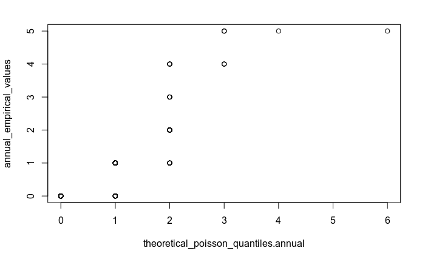

```r
# Annual
qqplot(theoretical_poisson_quantiles.annual, annual_empirical_values)
```

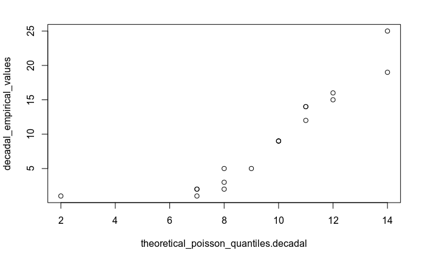

```r
# Decadal
qqplot(theoretical_poisson_quantiles.decadal, decadal_empirical_values)
```

COMPUTE FIT TO EXPONENTIAL DISTRIBUTION

```r
exponential.fit.annual <- fitdistr(annual_empirical_values, "exponential")
"---------Exponential Fit to Annual Empirical Values--------------"
```

```
[1] "---------Exponential Fit to Annual Empirical Values--------------"
```

```r
exponential.fit.annual
```

```
      rate
  1.10429448
 (0.08230925)
```

```r
exponential.fit.decadal <- fitdistr(decadal_empirical_values, "exponential")
"---------Exponential Fit to Decadal Empirical Values--------------"
```

```
[1] "---------Exponential Fit to Decadal Empirical Values--------------"
```

```r
exponential.fit.decadal
```

```
      rate
  0.11042945
 (0.02602847)
```

COMPUTE THEORETICAL EXPONENTIAL QUANTILES

```r
theoretical_exponential_quantiles.annual <- rexp(n = 180, rate = exponential.fit.annual$estimate)
"---------------Theoretical Exponential Quantiles (Annual)-----------------------------------"
```

```
[1] "---------------Theoretical Exponential Quantiles (Annual)-----------------------------------"
```

```r
theoretical_exponential_quantiles.annual
```

```
  [1] 3.18913661 1.52259637 1.47670797 1.15017832 0.13332991 2.37921664 0.67687016 0.28371831 0.32251699 0.22433229 1.29209623 1.94935614 0.42752271 0.93594071 0.30559060 0.34015816
 [17] 0.36591732 6.07909185 0.61326823 0.71215822 2.35251950 4.02644879 1.34365640 0.32718911 0.92207695 0.29791396 0.48084235 0.48525464 0.20088128 0.39581582 1.19872492 1.10337455
 [33] 1.35536269 0.48603430 0.39542121 0.09273190 2.66077643 0.08291026 0.56843210 0.68791098 0.34334819 0.88043757 0.57316917 1.12844189 0.92300731 0.08755242 1.23519548 2.19246609
 [49] 1.26047387 0.29756706 0.35256768 1.29016092 2.22120512 0.22941302 0.91888253 1.42979885 0.19888933 2.59890520 2.78587508 0.08905220 1.10999516 1.13859549 0.09422526 1.40833187
 [65] 1.64973068 0.58300243 0.74868323 0.50177505 1.71406751 1.96434653 2.46918018 0.42955884 1.92769971 0.07251912 2.48397278 0.92248702 1.63354330 2.01855317 0.09375308 0.05470390
 [81] 0.07767633 0.27841760 0.51188949 2.41822942 0.24985980 1.41238945 1.96004289 0.77288466 0.36125794 2.05123850 2.66961877 0.89934889 0.72831009 1.11991043 0.18936054 2.93159914
 [97] 0.06350394 2.91540569 0.89993087 0.47589311 1.44928664 0.48618690 2.21372552 0.21326244 1.80808387 1.13177928 1.77463674 1.38288394 0.12046222 1.26223886 6.34376133 0.84990941
[113] 1.69041608 1.93128781 1.50920116 2.80312063 2.60136520 0.53271586 1.12332989 0.03252997 0.26752415 0.62221782 0.22088965 0.02152114 1.76619943 0.20771611 0.90727713 0.94925045
[129] 0.04409576 0.88020396 0.62546000 0.15919799 0.54392419 0.96385794 0.33705937 0.04015146 0.53555061 0.19918620 0.21004555 1.95829598 0.97908088 0.52800611 0.57346362 2.87175093
[145] 1.96098141 0.76080535 0.29045620 0.35423612 1.53424198 0.96706960 0.18348236 1.59540065 0.77118690 0.49524059 0.71739091 0.10573877 0.66497110 1.11726701 0.50332541 1.11976493
[161] 0.26980606 0.12831627 0.14046774 0.77991360 0.59024006 1.66067230 0.91616805 0.55747529 1.76363100 0.13806823 0.29698435 1.76597393 0.08760558 1.11391793 0.20755853 0.41042154
[177] 0.57256828 1.97643410 0.54039594 0.05585395
```

```r
"-----------------------------------------------------------------------------------------"
```

```
[1] "-----------------------------------------------------------------------------------------"
```

```r
theoretical_exponential_quantiles.decadal <- rexp(n = 18, rate = exponential.fit.decadal$estimate)
"---------------Theoretical Exponential Quantiles (Decadal)-----------------------------------"
```

```
[1] "---------------Theoretical Exponential Quantiles (Decadal)-----------------------------------"
```

```r
theoretical_exponential_quantiles.decadal
```

```
 [1]  1.480412  5.249165  2.117426 13.146974 11.254651  2.237328 12.642489  1.909841 37.178189  3.543988  1.827629  9.901476  4.445161 22.316301 51.383693 11.103404  7.011056  0.529013
```

PLOT QUANTILE-QUANTILE PLOT FOR EMPIRICAL VALUES AND THEORETICAL VALUES

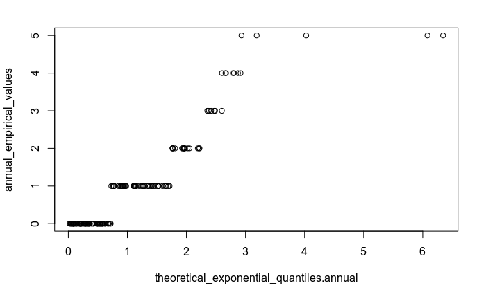

```r
# Annual
qqplot(theoretical_exponential_quantiles.annual, annual_empirical_values)
```

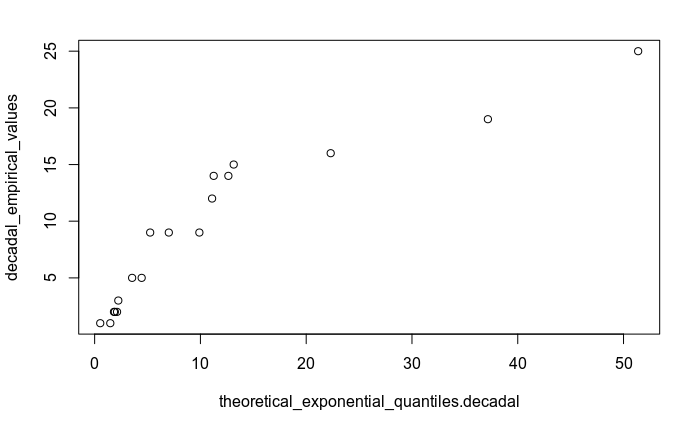

```r
# Decadal
qqplot(theoretical_exponential_quantiles.decadal, decadal_empirical_values)
```

COMPUTE FIT TO CAUCHY DISTRIBUTION

```r
cauchy.fit.annual <- fitdistr(annual_empirical_values, "cauchy")
```

```
NaNs producedNaNs producedNaNs producedNaNs producedNaNs producedNaNs producedNaNs produced
```

```r
"---------Cauchy Fit to Annual Empirical Values--------------"
```

```
[1] "---------Cauchy Fit to Annual Empirical Values--------------"
```

```r
cauchy.fit.annual
```

```
   location      scale
  0.1561870   0.4247695
 (0.1025443) (0.1179267)
```

```r
cauchy.fit.decadal <- fitdistr(decadal_empirical_values, "cauchy")
"---------Cauchy Fit to Decadal Empirical Values--------------"
```

```
[1] "---------Cauchy Fit to Decadal Empirical Values--------------"
```

```r
cauchy.fit.decadal
```

```
   location     scale
  7.612185    4.931809
 (2.275553)  (1.362343)
```

COMPUTE THEORETICAL CAUCHY QUANTILES

```r
theoretical_cauchy_quantiles.annual <- rcauchy(n = 180, location = cauchy.fit.annual$estimate[1], scale = cauchy.fit.annual$estimate[2])
"---------------Theoretical Cauchy Quantiles (Annual)-----------------------------------"
```

```
[1] "---------------Theoretical Cauchy Quantiles (Annual)-----------------------------------"
```

```r
theoretical_cauchy_quantiles.annual
```

```
  [1]   0.253628427  -0.309941637   0.048587765   0.524371548   0.442623158   0.440893469  -4.725253428  -0.366249387  -0.988060076   1.201899149   0.054462719   8.574326129
 [13]   0.726820343  -0.912218676  -0.272932426   0.617603307   0.221493595   0.211864236   0.780856409   0.885338364   0.886301996  -0.067133001  -0.130793267  -0.184531541
 [25]   0.345992414  -0.697237159   0.272234682   1.177350873 -18.524856251   0.131322678  -0.145957800   0.240316911   1.739639602   0.764587110   0.009029129  -6.360256609
 [37]   0.291399573  -0.100430299  -1.529427640  -0.290224078   0.018701553  -0.224590141   0.063676942  -0.537042864   0.341489089   0.415211440  -0.216144386  -1.888631201
 [49]   0.104458216   0.417344347   1.421937949  -0.612166386  -0.256730093   0.504200234   0.539848985   0.121184907   0.808870133  -1.168452049  53.701329305  -1.071752086
 [61]  -0.071861679   0.009294161   0.675826119  -2.024975392  -4.296173068   0.245354798   0.226930747   1.094187601   4.994991945  -0.556585283  -0.279970581   1.116991756
 [73]  -0.319886846   0.172706904  -1.017856825   0.265533625   0.033418661  -0.005578975  -0.040183758  -0.756598642   0.035407520  -0.081295746  -0.372152634  -0.744050311
 [85]   0.085601435   0.575315798   0.130858437   3.258138963   4.508427209   0.853681388  10.355426010   0.126697265   0.375117520  -1.682180547   8.556835830   1.031182731
 [97]  -1.497690686  -0.475309138   0.683997116  -0.706562678   0.120233059   0.547936030   0.138625408 242.927356680   0.085157166  -0.087732350   0.195011775   0.190529357
[109]  -0.025044698  -7.449982617   0.143284568   0.686237319   0.192707055   0.671123092   0.035068183   0.326491113  -6.832905984  -9.691135304  -0.169321834   0.076303756
[121]  29.022880125   0.253515534  -0.785767973   2.411184589   2.985615684  25.609780598   0.043596588  -0.137648283   0.185272798   0.338919972   0.019392967   1.022675418
[133]  -0.553273602   0.720477932   2.073623430   0.066941144   0.654633049 -14.412367212   0.259477088   1.806623488  -0.046150081  -0.997233893  -0.106782205   1.043913984
[145]   0.030604746   0.504099564   2.212311463   0.218551707  -0.013104578  -0.179780615  -0.284276815  18.705442492   0.421201313  -0.526167501   0.028953108   0.013022350
[157]  -0.748582239   0.407250136  -0.481200409   0.385177025  -0.096963775   1.826205339   0.365607466  -0.372315297   5.571272689  -1.013920592   0.277567624  -0.321544059
[169]   0.264196178   0.086385240   0.001380000 -19.433390806   0.480089122   0.285820655  -0.833725613  -1.862052032   0.384544506 -10.071180464   1.031665417  -0.254656593
```

```r
"-----------------------------------------------------------------------------------------"
```

```
[1] "-----------------------------------------------------------------------------------------"
```

```r
theoretical_cauchy_quantiles.decadal <- rcauchy(n = 18, location = cauchy.fit.decadal$estimate[1], scale = cauchy.fit.decadal$estimate[2])
"---------------Theoretical Cauchy Quantiles (Decadal)-----------------------------------"
```

```
[1] "---------------Theoretical Cauchy Quantiles (Decadal)-----------------------------------"
```

```r
theoretical_cauchy_quantiles.decadal
```

```
 [1]   7.313072   8.578358   7.571388 -27.251856  66.899486  12.781234  49.402395   2.891362  14.069736  19.129715   8.702166  -1.676369 -48.359723 -69.905550  15.323291  67.194753
[17]  15.836437   3.711482
```

PLOT QUANTILE-QUANTILE PLOT FOR EMPIRICAL VALUES AND THEORETICAL VALUES

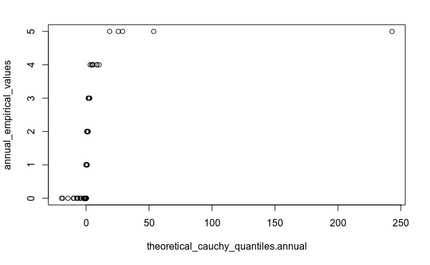

```r
# Annual
qqplot(theoretical_cauchy_quantiles.annual, annual_empirical_values)
```

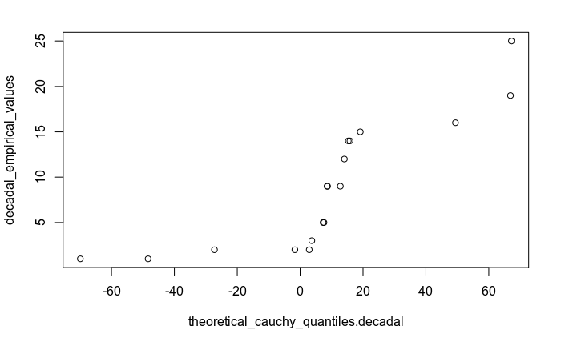

```r
# Decadal
qqplot(theoretical_cauchy_quantiles.decadal, decadal_empirical_values)
```

COMPUTE FIT TO LOGISTIC DISTRIBUTION

```r
logistic.fit.annual <- fitdistr(annual_empirical_values, "logistic")
```

```
NaNs producedNaNs producedNaNs produced
```

```r
"---------Logistic Fit to Annual Empirical Values--------------"
```

```
[1] "---------Logistic Fit to Annual Empirical Values--------------"
```

```r
logistic.fit.annual
```

```
    location      scale
  0.69955213   0.61852145
 (0.07867463) (0.03945404)
```

```r
logistic.fit.decadal <- fitdistr(decadal_empirical_values, "logistic")
"---------Logistic Fit to Decadal Empirical Values--------------"
```

```
[1] "---------Logistic Fit to Decadal Empirical Values--------------"
```

```r
logistic.fit.decadal
```

```
   location      scale
  8.5968452   4.0482418
 (1.6987531) (0.7731502)
```

COMPUTE THEORETICAL LOGISTIC QUANTILES

```r
theoretical_logistic_quantiles.annual <- rlogis(n = 180, location = logistic.fit.annual$estimate[1], scale = logistic.fit.annual$estimate[2])
"---------------Theoretical Logistic Quantiles (Annual)-----------------------------------"
```

```
[1] "---------------Theoretical Logistic Quantiles (Annual)-----------------------------------"
```

```r
theoretical_logistic_quantiles.annual
```

```
  [1] -1.14424550  0.31172473  1.68797536 -0.48639286 -0.11277806  1.06394323  1.31632654  0.36314477  0.25569248  0.80624556  1.38519755 -0.15873624  2.04906751  0.10486461  0.51298273
 [16]  1.03710064  2.57243281 -0.07921353  1.32693308 -2.36463826  2.62497659  0.28562984 -0.86893227  0.89652550  2.00705118  1.10189501 -2.37167893  1.07593401  2.11014190  0.50886857
 [31] -0.16392303  0.91086360  1.00501412  2.47544055  0.73063151  1.44069459  3.93649115  0.69184964 -1.28166114  0.05446714  0.67192657 -0.93078126 -0.49227956  0.85976813  0.64579925
 [46]  0.81337771 -0.42340160  1.07733188  1.29129107 -0.11206166 -1.10591598 -0.30223768  0.21549606  1.67183673  2.62056769  0.73350183  1.22328118  0.76091509  0.71842983  1.78805384
 [61] -0.64858234  1.32026593  0.54496050 -0.62871466 -0.35235167 -1.49061403 -0.06221372 -0.20310552  1.95072712  1.39721862 -1.64125073 -2.58230838  1.27412355 -0.81720854  0.81517249
 [76] -0.71597660  1.06659071  0.55257586 -0.23531195  1.88545373  1.77826166 -0.16348376  2.06929923  1.65348145  4.83936177 -0.23702467  0.16464770 -0.15006186  0.45058645  1.32833940
 [91]  1.66882349  1.57128768 -0.87597549 -0.01761006  0.29508674  0.89686612 -2.04708378  0.37923528  0.64968764  0.23264495 -0.74095574 -1.21735978  0.66131284  1.71777224  2.10990072
[106]  1.58044427  0.67024601  2.01679397  0.90907964 -2.43488193  1.02583324  1.70478909 -0.42834535 -0.07403071  2.60559378  0.58365104  0.12714399  1.65888121  1.25135033  0.59962386
[121] -1.21964808  0.14033648  0.73767750  1.59630294  1.54632840  1.30589095  2.10100600  0.55944554 -0.09827116  3.24509981 -0.36551727  1.56865489 -1.63998598  1.54973737  0.63939712
[136] -1.52651980 -0.92527741  0.71626182 -0.20103933  0.01514650  0.83315555  0.07440991  0.83319812  1.30794286 -1.52381791 -1.77955904  0.99281712  0.26714467  1.17990908 -1.48763558
[151]  2.48662100  0.62169946  0.03212061  0.15391819  0.95176286  1.03413372 -0.41328266  1.24887108 -0.51960038  1.17198452  1.75614829 -1.24143089 -0.22295604  1.34587904 -0.04430899
[166]  2.28769450  0.66239358 -0.09843600 -0.42025625 -1.07409830 -0.22353149  2.06848446  1.49812941 -1.35922701 -0.49732694  0.98597208  1.45062079  0.84967673  0.52353833 -0.21304017
```

```r
"-----------------------------------------------------------------------------------------"
```

```
[1] "-----------------------------------------------------------------------------------------"
```

```r
theoretical_logistic_quantiles.decadal <- rlogis(n = 18, location = logistic.fit.decadal$estimate[1], scale = logistic.fit.decadal$estimate[2])
"---------------Theoretical Logistic Quantiles (Decadal)-----------------------------------"
```

```
[1] "---------------Theoretical Logistic Quantiles (Decadal)-----------------------------------"
```

```r
theoretical_logistic_quantiles.decadal
```

```
 [1] 13.6222611 -8.6027416  6.7644606  7.8792496  1.5191270 11.1680631 12.3027960  2.3896136 10.4742971 -0.2462333  5.0726236  7.1080632 11.7252341  2.3302107  5.4752731 -4.8917654
[17] 14.4153895 -6.9381623
```

PLOT QUANTILE-QUANTILE PLOT FOR EMPIRICAL VALUES AND THEORETICAL VALUES

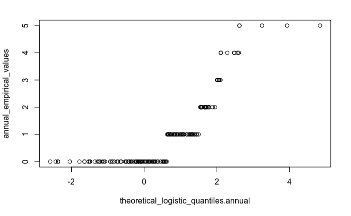

```r
# Annual
qqplot(theoretical_logistic_quantiles.annual, annual_empirical_values)
```

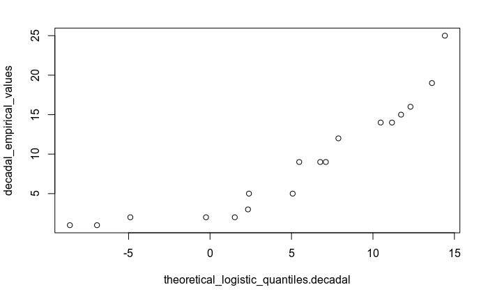

```r
# Decadal
qqplot(theoretical_logistic_quantiles.decadal, decadal_empirical_values)
```

PERFORM AMO ANALYSIS

READ AMO DATA

```r
amo_monthly_data <- read.csv("data/amo_monthly_data.csv")
head(amo_monthly_data)
```

```
  Year   Jan   Feb   Mar   Apr   May   Jun   Jul   Aug   Sep   Oct   Nov   Dec
1 1870 -0.02 -0.02 -0.01 -0.01 -0.01 -0.01 -0.01 -0.01 -0.01 -0.01 -0.01 -0.01
2 1871 -0.01 -0.01 -0.01 -0.01 -0.01 -0.01 -0.01 -0.01 -0.01  0.00  0.00  0.00
3 1872  0.00  0.00  0.00  0.00  0.00  0.00  0.00  0.00  0.00  0.00  0.00  0.00
4 1873  0.00  0.00  0.00  0.01  0.01  0.01  0.02  0.02  0.02  0.02  0.02  0.02
5 1874  0.03  0.03  0.03  0.03  0.03  0.03  0.03  0.03  0.02  0.02  0.02  0.03
6 1875  0.03  0.03  0.02  0.02  0.02  0.02  0.02  0.02  0.02  0.02  0.02  0.02
```

COMPUTE AVERAGE ANNUAL AMO DEPARTURES

```r
amo_annual_data <- data.frame(cbind(Years = amo_monthly_data[,1], Means = rowMeans(amo_monthly_data[,-1])))
head(amo_annual_data)
```

```
  Years       Means
1  1870 -0.01166667
2  1871 -0.00750000
3  1872  0.00000000
4  1873  0.01250000
5  1874  0.02750000
6  1875  0.02166667
```

```r
colnames(amo_annual_data) <- c("Years", "Avg_Annual_AMO_Departure")
head(amo_annual_data)
```

```
  Years Avg_Annual_AMO_Departure
1  1870              -0.01166667
2  1871              -0.00750000
3  1872               0.00000000
4  1873               0.01250000
5  1874               0.02750000
6  1875               0.02166667
```

PLOT AMO GRAPH ALONGSIDE ANNUAL AND DECADAL HURRICANE FREQUENCY DISTRIBUTIONS

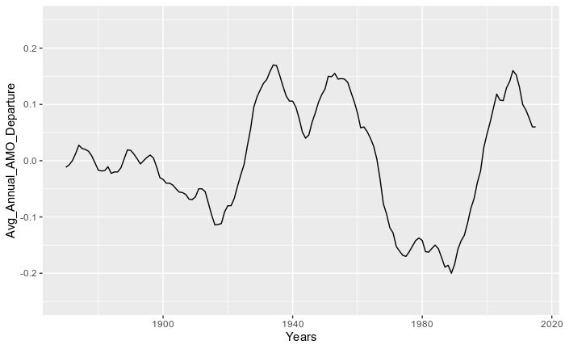

```r
# Plotting AMO Graph
ggplot(data.frame(amo_annual_data) %>% filter(between(amo_annual_data$Years, 1851, 2015)), aes(x=Years, y=Avg_Annual_AMO_Departure)) + geom_line() + ylim(-0.25, 0.25)
```

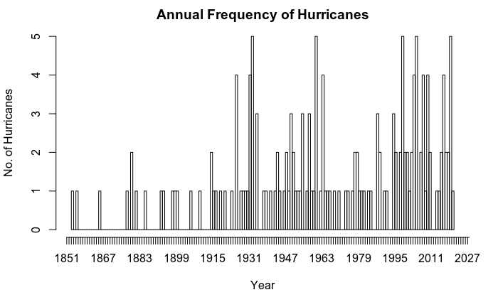

```r
# Plotting Annual Frequency Distribution
hist(data$Year, breaks = length(annual_empirical_values), main = "Annual Frequency of Hurricanes", xlab = "Year", ylab = "No. of Hurricanes", xaxt = 'n')
axis(side=1, at=seq(1851, 2030, 1), labels=seq(1851, 2030, 1))
```

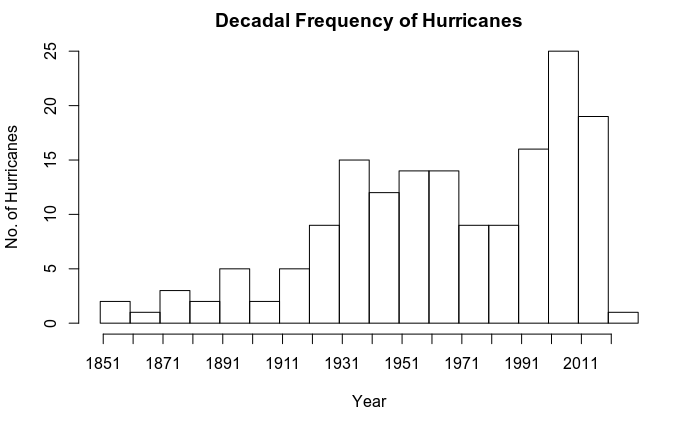

```r
# Plotting Decadal Frequency Distribution
hist(data$decade, breaks = length(decadal_empirical_values), main = "Decadal Frequency of Hurricanes", xlab = "Year", ylab = "No. of Hurricanes", xaxt = 'n')
axis(side=1, at=seq(1851, 2030, 10), labels=seq(1851, 2030, 10))
```